# Week 02: R for Data Analytics

Ziyuan Huang

Last Updated: November 13, 2025

# Introduction

## 1. Overview

This tutorial demonstrates how to use R to perform **data analytics** tasks covered in Week 02. We’ll explore:

- **Descriptive Analytics**: Understanding what happened
- **Predictive Analytics**: Predicting what could happen
- **Prescriptive Analytics**: Determining what should happen

## 2. Learning Objectives

By the end of this tutorial, you will be able to:

1. Load and explore datasets in R
2. Calculate descriptive statistics (central tendency, dispersion)
3. Create frequency distributions and visualizations
4. Understand different variable types and measurements
5. Build simple predictive models
6. Apply the research process using R

## 3. Required Packages

```r
# Install packages if needed (uncomment to install)
# install.packages(c("tidyverse", "ggplot2", "dplyr", "knitr", "kableExtra"))
# install.packages("seedhash")  # For reproducible seed generation

# Load required packages
library(tidyverse)    # Data manipulation and visualization
library(ggplot2)      # Advanced plotting
library(dplyr)        # Data manipulation
library(knitr)        # Table formatting
library(kableExtra)   # Enhanced tables
library(seedhash)     # Reproducible seed generation

# Display seed information
cat("\n=== REPRODUCIBLE SEED INFORMATION ===")
```

```
##
## === REPRODUCIBLE SEED INFORMATION ===
```

```r
cat("\nGenerator Name: Ziyuan Huang")
```

```
##
## Generator Name: Ziyuan Huang
```

```r
cat("\nMD5 Hash:", gen$get_hash())
```

```
##
## MD5 Hash: 0e112cb70d324ea5e5b9f803b4488bde
```

```r
cat("\nAvailable Seeds:", paste(seeds[1:5], collapse = ", "), "...\n\n")
```

```
##
## Available Seeds: -805293604, -909845485, -339394968, 586956699, -960637137 ...
```

# Part 1: Understanding Data Types

## 1.1 Variable Types in R

R handles different types of variables. Let’s explore them:

```r
# Numeric (continuous) variables
age <- 25
height <- 175.5
temperature <- 98.6

# Integer variables
num_students <- 30L
year <- 2025L

# Character (string) variables
name <- "John Doe"
city <- "Washington DC"

# Logical (boolean) variables
is_student <- TRUE
passed_exam <- FALSE

# Factor (categorical) variables
education_level <- factor(c("High School", "Bachelor", "Master", "PhD"))
grade <- factor(c("A", "B", "C", "D", "F"), ordered = TRUE)

# Check variable types
cat("Type of age:", class(age), "\n")
```

```
## Type of age: numeric
```

```r
cat("Type of name:", class(name), "\n")
```

```
## Type of name: character
```

```r
cat("Type of is_student:", class(is_student), "\n")
```

```
## Type of is_student: logical
```

```r
cat("Type of education_level:", class(education_level), "\n")
```

```
## Type of education_level: factor
```

## 1.2 Categorical Variables

### 1.2.1 Binary Variables

```r
# Binary variable example: Pass/Fail
pass_fail <- c("Pass", "Fail", "Pass", "Pass", "Fail")
pass_fail_factor <- factor(pass_fail)

cat("Binary variable levels:", levels(pass_fail_factor), "\n")
```

```
## Binary variable levels: Fail Pass
```

```r
table(pass_fail_factor)
```

```
## pass_fail_factor
## Fail Pass
##    2    3
```

### 1.2.2 Nominal Variables

```r
# Nominal: Categories without order
departments <- factor(c("HR", "IT", "Finance", "Marketing", "IT", "HR", "Finance"))

cat("Department frequency:\n")
```

```
## Department frequency:
```

```r
table(departments)
```

```
## departments
##   Finance        HR        IT Marketing
##         2         2         2         1
```

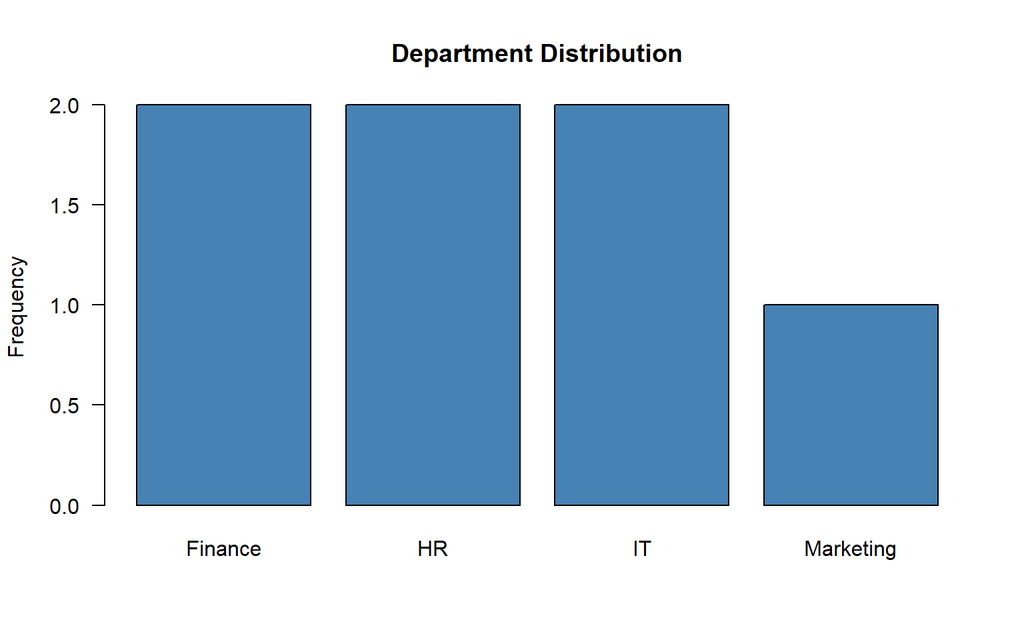

```r
# Visualize
barplot(table(departments),
        main = "Department Distribution",
        col = "steelblue",
        ylab = "Frequency",
        las = 1)
```

### 1.2.3 Ordinal Variables

```r
# Ordinal: Categories with logical order
satisfaction <- factor(
  c("Very Unsatisfied", "Unsatisfied", "Neutral", "Satisfied", "Very Satisfied",
    "Satisfied", "Neutral", "Very Satisfied", "Satisfied", "Unsatisfied"),
  levels = c("Very Unsatisfied", "Unsatisfied", "Neutral", "Satisfied", "Very Satisfied"),
  ordered = TRUE
)

cat("Satisfaction levels:\n")
```

```
## Satisfaction levels:
```

```r
print(table(satisfaction))
```

```
## satisfaction
## Very Unsatisfied      Unsatisfied          Neutral        Satisfied
##                1                2                2                3
##   Very Satisfied
##                2
```

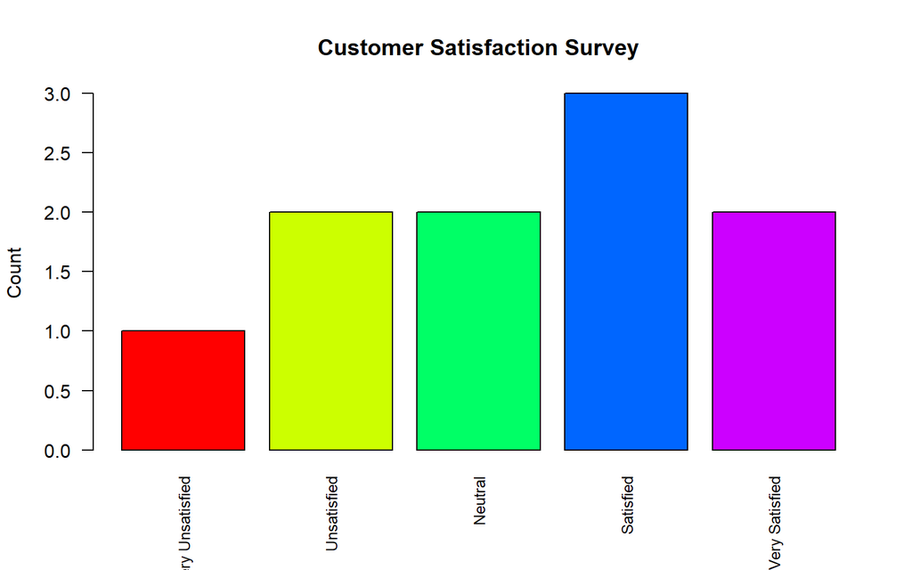

```r
# Visualize with ordered categories
barplot(table(satisfaction),
        main = "Customer Satisfaction Survey",
        col = rainbow(5),
        ylab = "Count",
        las = 2,
        cex.names = 0.8)
```

## 1.3 Continuous Variables

### 1.3.1 Interval Variables

```r
# Interval: Equal intervals but no true zero (e.g., temperature in Celsius)
temperatures <- c(15, 18, 22, 25, 20, 16, 19, 23, 21, 17)

cat("Temperature Statistics:\n")
```

```
## Temperature Statistics:
```

```r
cat("Mean:", mean(temperatures), "°C\n")
```

```
## Mean: 19.6 °C
```

```r
cat("Median:", median(temperatures), "°C\n")
```

```
## Median: 19.5 °C
```

```r
cat("Range:", range(temperatures)[1], "to", range(temperatures)[2], "°C\n")
```

```
## Range: 15 to 25 °C
```

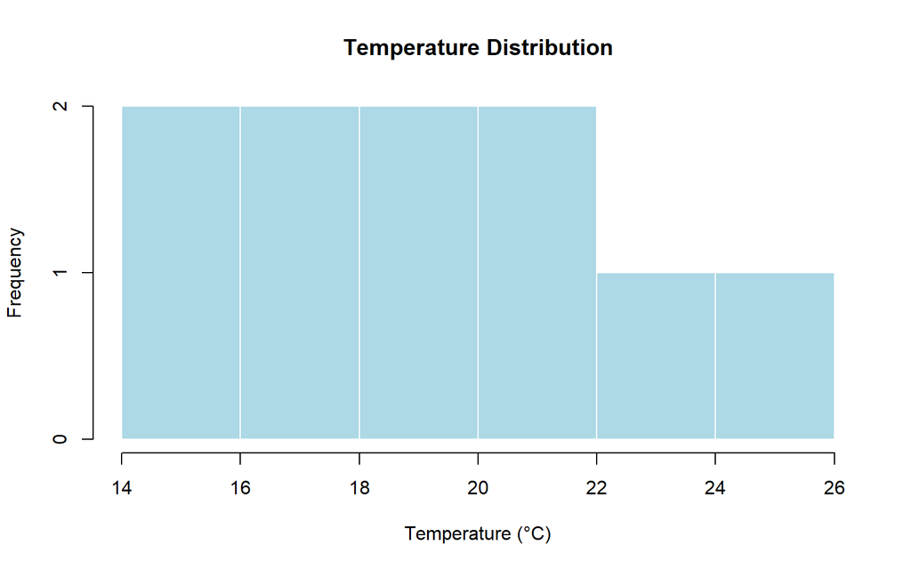

```r
# Note: 0°C doesn't mean "no temperature"
hist(temperatures,
     main = "Temperature Distribution",
     xlab = "Temperature (°C)",
     col = "lightblue",
     border = "white")
```

### 1.3.2 Ratio Variables

```r
# Ratio: Equal intervals AND true zero (e.g., height, weight, income)
heights <- c(160, 175, 182, 168, 155, 190, 172, 165, 178, 185)

cat("Height Statistics:\n")
```

```
## Height Statistics:
```

```r
cat("Mean:", mean(heights), "cm\n")
```

```
## Mean: 173 cm
```

```r
cat("Median:", median(heights), "cm\n")
```

```
## Median: 173.5 cm
```

```r
cat("Note: 0 cm would mean no height (true zero)\n")
```

```
## Note: 0 cm would mean no height (true zero)
```

```r
# Ratio calculations make sense
cat("\nRatio example: 180cm is", 180/90, "times taller than 90cm\n")
```

```
##
## Ratio example: 180cm is 2 times taller than 90cm
```

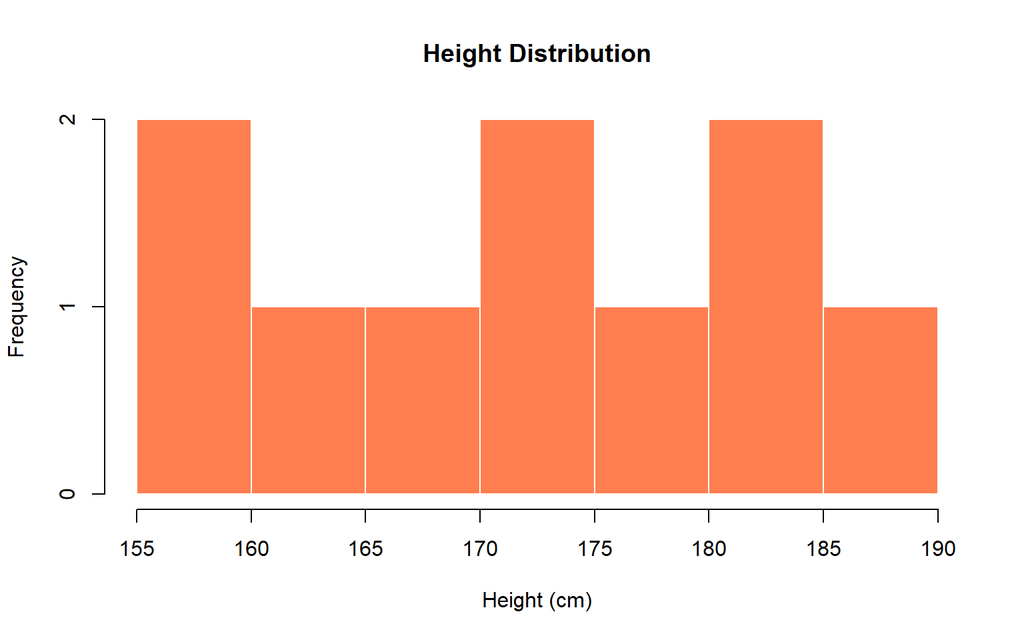

```r
hist(heights,
     main = "Height Distribution",
     xlab = "Height (cm)",
     col = "coral",
     border = "white")
```

# Part 2: Descriptive Analytics

## 2.1 Loading Data

Let’s work with built-in R datasets and real examples:

```r
# Load built-in datasets
data(iris)        # Famous flower dataset
data(mtcars)      # Motor cars data
data(airquality)  # Air quality measurements

# Preview datasets
cat("Iris dataset (first 6 rows):\n")
```

```
## Iris dataset (first 6 rows):
```

```r
head(iris) %>% kable() %>% kable_styling(bootstrap_options = c("striped", "hover"))
```

| Sepal.Length | Sepal.Width | Petal.Length | Petal.Width | Species |
| --- | --- | --- | --- | --- |
| 5.1 | 3.5 | 1.4 | 0.2 | setosa |
| 4.9 | 3.0 | 1.4 | 0.2 | setosa |
| 4.7 | 3.2 | 1.3 | 0.2 | setosa |
| 4.6 | 3.1 | 1.5 | 0.2 | setosa |
| 5.0 | 3.6 | 1.4 | 0.2 | setosa |
| 5.4 | 3.9 | 1.7 | 0.4 | setosa |

## 2.2 Central Tendency Measures

### 2.2.1 The Mean

```r
# Calculate mean
sepal_lengths <- iris$Sepal.Length

mean_value <- mean(sepal_lengths)
cat("Mean Sepal Length:", round(mean_value, 2), "cm\n")
```

```
## Mean Sepal Length: 5.84 cm
```

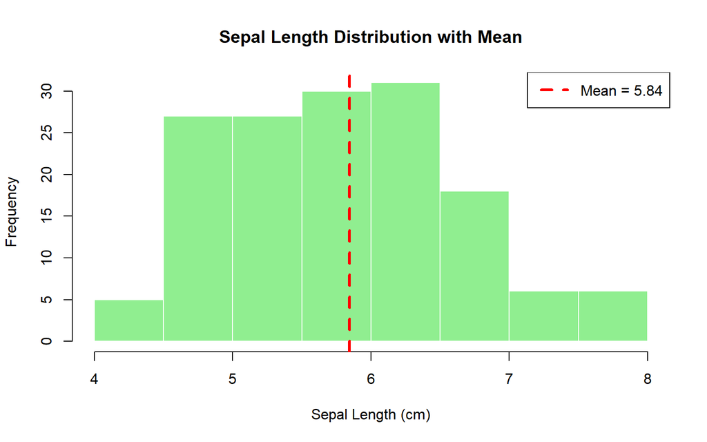

```r
# Visualize with mean line
hist(sepal_lengths,
     main = "Sepal Length Distribution with Mean",
     xlab = "Sepal Length (cm)",
     col = "lightgreen",
     border = "white")
abline(v = mean_value, col = "red", lwd = 3, lty = 2)
legend("topright", legend = paste("Mean =", round(mean_value, 2)),
       col = "red", lty = 2, lwd = 3)
```

**Understanding the Mean:**

$$\bar{X} = \frac{\sum_{i=1}^{n} x_i}{n} =
\frac{x_1 + x_2 + ... + x_n}{n}$$

```r
# Manual calculation to understand the formula
sum_values <- sum(sepal_lengths)
n_values <- length(sepal_lengths)
manual_mean <- sum_values / n_values

cat("Sum of values:", sum_values, "\n")
```

```
## Sum of values: 876.5
```

```r
cat("Number of values:", n_values, "\n")
```

```
## Number of values: 150
```

```r
cat("Manual mean calculation:", round(manual_mean, 2), "\n")
```

```
## Manual mean calculation: 5.84
```

```r
cat("R's mean() function:", round(mean(sepal_lengths), 2), "\n")
```

```
## R's mean() function: 5.84
```

### 2.2.2 The Median

```r
# Calculate median
median_value <- median(sepal_lengths)

cat("Median Sepal Length:", round(median_value, 2), "cm\n")
```

```
## Median Sepal Length: 5.8 cm
```

```r
cat("Mean Sepal Length:", round(mean_value, 2), "cm\n")
```

```
## Mean Sepal Length: 5.84 cm
```

```r
cat("Difference:", round(abs(mean_value - median_value), 3), "cm\n")
```

```
## Difference: 0.043 cm
```

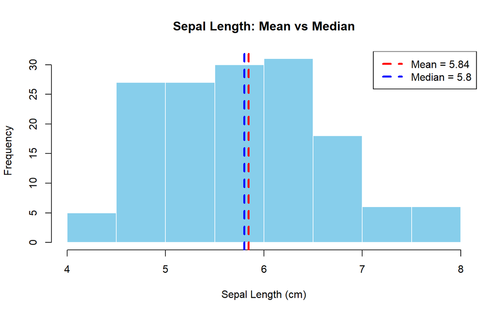

```r
# Visualize both
hist(sepal_lengths,
     main = "Sepal Length: Mean vs Median",
     xlab = "Sepal Length (cm)",
     col = "skyblue",
     border = "white")
abline(v = mean_value, col = "red", lwd = 3, lty = 2)
abline(v = median_value, col = "blue", lwd = 3, lty = 2)
legend("topright",
       legend = c(paste("Mean =", round(mean_value, 2)),
                  paste("Median =", round(median_value, 2))),
       col = c("red", "blue"),
       lty = 2,
       lwd = 3)
```

**Finding the Median:**

For odd number of values: Middle value For even number of values: Average of two middle values

```r
# Example with manual calculation
facebook_friends <- c(22, 40, 53, 57, 93, 98, 103, 108, 116, 121, 252)
sorted_friends <- sort(facebook_friends)

cat("Sorted values:", sorted_friends, "\n")
```

```
## Sorted values: 22 40 53 57 93 98 103 108 116 121 252
```

```r
cat("Position of median: (n+1)/2 = (11+1)/2 =", (length(sorted_friends)+1)/2, "\n")
```

```
## Position of median: (n+1)/2 = (11+1)/2 = 6
```

```r
cat("Median value:", median(facebook_friends), "\n")
```

```
## Median value: 98
```

```r
# Remove extreme value
friends_no_extreme <- facebook_friends[facebook_friends != 252]
cat("\nWithout extreme value (252):\n")
```

```
##
## Without extreme value (252):
```

```r
cat("New median:", median(friends_no_extreme), "\n")
```

```
## New median: 95.5
```

```r
cat("Change:", median(facebook_friends) - median(friends_no_extreme), "\n")
```

```
## Change: 2.5
```

### 2.2.3 The Mode

```r
# R doesn't have a built-in mode function, so we create one
get_mode <- function(x) {
  unique_vals <- unique(x)
  freq_table <- tabulate(match(x, unique_vals))
  unique_vals[which.max(freq_table)]
}

# Example with discrete data
grades <- c("A", "B", "B", "C", "B", "A", "C", "B", "D", "B", "C")
mode_grade <- get_mode(grades)

cat("Mode (most frequent grade):", mode_grade, "\n")
```

```
## Mode (most frequent grade): B
```

```r
cat("\nFrequency table:\n")
```

```
##
## Frequency table:
```

```r
print(table(grades))
```

```
## grades
## A B C D
## 2 5 3 1
```

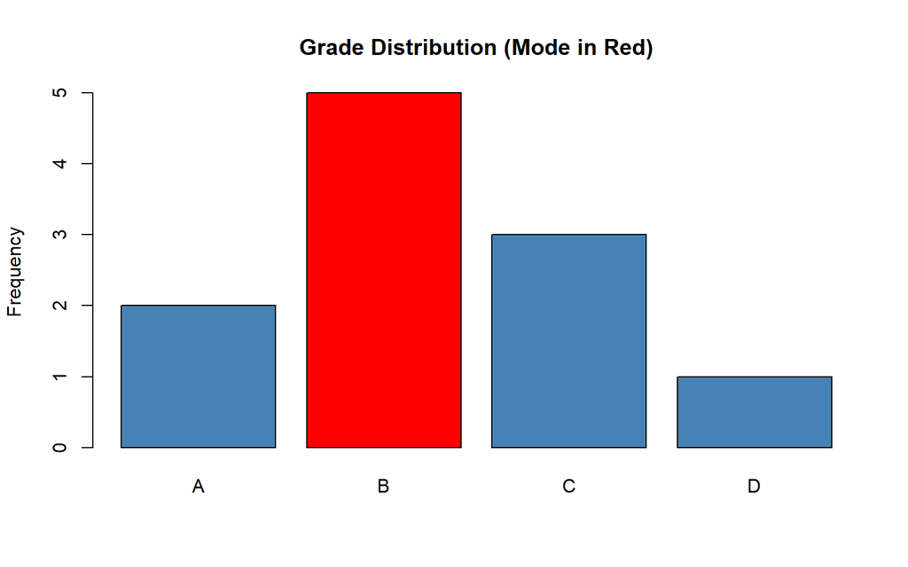

```r
# Visualize
barplot(table(grades),
        main = "Grade Distribution (Mode in Red)",
        col = ifelse(names(table(grades)) == mode_grade, "red", "steelblue"),
        ylab = "Frequency")
```

### 2.2.4 Comparing Central Tendency Measures

```r
# Create a comparison table
iris_summary <- iris %>%
  group_by(Species) %>%
  summarise(
    Mean = mean(Sepal.Length),
    Median = median(Sepal.Length),
    Min = min(Sepal.Length),
    Max = max(Sepal.Length),
    N = n()
  ) %>%
  mutate(across(where(is.numeric), ~round(., 2)))

iris_summary %>%
  kable(caption = "Central Tendency by Species") %>%
  kable_styling(bootstrap_options = c("striped", "hover", "condensed"))
```

Central Tendency by Species

| Species | Mean | Median | Min | Max | N |
| --- | --- | --- | --- | --- | --- |
| setosa | 5.01 | 5.0 | 4.3 | 5.8 | 50 |
| versicolor | 5.94 | 5.9 | 4.9 | 7.0 | 50 |
| virginica | 6.59 | 6.5 | 4.9 | 7.9 | 50 |

## 2.3 Measures of Dispersion

### 2.3.1 Range

```r
# Calculate range
range_vals <- range(sepal_lengths)
range_value <- diff(range_vals)

cat("Minimum:", range_vals[1], "\n")
```

```
## Minimum: 4.3
```

```r
cat("Maximum:", range_vals[2], "\n")
```

```
## Maximum: 7.9
```

```r
cat("Range:", range_value, "\n")
```

```
## Range: 3.6
```

```r
# Effect of extreme values
cat("\nEffect of extreme values:\n")
```

```
##
## Effect of extreme values:
```

```r
cat("Original range:", diff(range(facebook_friends)), "\n")
```

```
## Original range: 230
```

```r
cat("Without extreme (252):", diff(range(friends_no_extreme)), "\n")
```

```
## Without extreme (252): 99
```

```r
cat("Reduction:", diff(range(facebook_friends)) - diff(range(friends_no_extreme)), "\n")
```

```
## Reduction: 131
```

### 2.3.2 Interquartile Range (IQR)

```r
# Calculate quartiles
q1 <- quantile(sepal_lengths, 0.25)
q2 <- quantile(sepal_lengths, 0.50)  # This is the median
q3 <- quantile(sepal_lengths, 0.75)
iqr_value <- IQR(sepal_lengths)

cat("Lower Quartile (Q1):", q1, "\n")
```

```
## Lower Quartile (Q1): 5.1
```

```r
cat("Median (Q2):", q2, "\n")
```

```
## Median (Q2): 5.8
```

```r
cat("Upper Quartile (Q3):", q3, "\n")
```

```
## Upper Quartile (Q3): 6.4
```

```r
cat("Interquartile Range (IQR):", iqr_value, "\n")
```

```
## Interquartile Range (IQR): 1.3
```

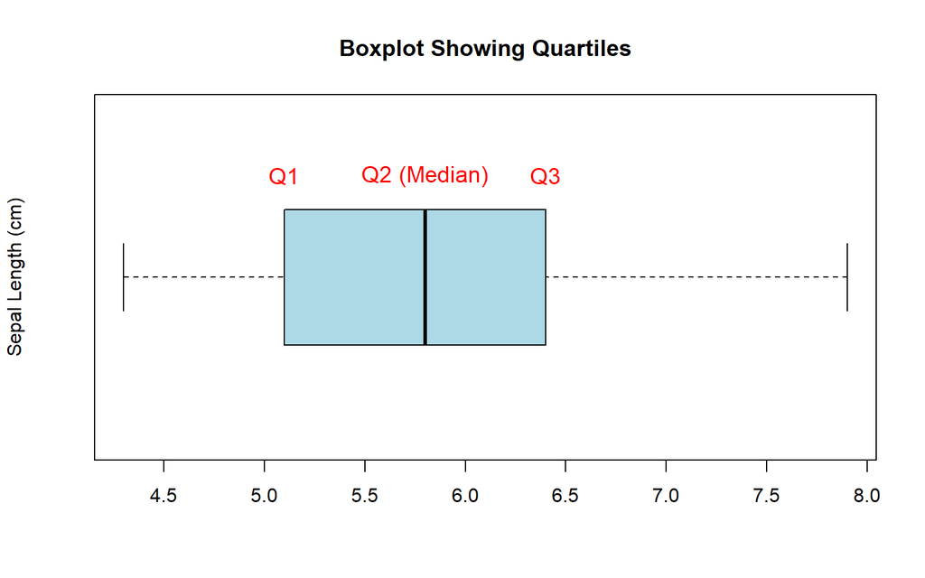

```r
# Boxplot shows quartiles
boxplot(sepal_lengths,
        main = "Boxplot Showing Quartiles",
        ylab = "Sepal Length (cm)",
        col = "lightblue",
        horizontal = TRUE)
text(x = q1, y = 1.3, labels = "Q1", col = "red", cex = 1.2)
text(x = q2, y = 1.3, labels = "Q2 (Median)", col = "red", cex = 1.2)
text(x = q3, y = 1.3, labels = "Q3", col = "red", cex = 1.2)
```

### 2.3.3 Variance and Standard Deviation

```r
# Calculate variance and standard deviation
var_value <- var(sepal_lengths)
sd_value <- sd(sepal_lengths)

cat("Variance:", round(var_value, 4), "\n")
```

```
## Variance: 0.6857
```

```r
cat("Standard Deviation:", round(sd_value, 4), "\n")
```

```
## Standard Deviation: 0.8281
```

```r
cat("\nInterpretation:\n")
```

```
##
## Interpretation:
```

```r
cat("On average, sepal lengths deviate by", round(sd_value, 2), "cm from the mean.\n")
```

```
## On average, sepal lengths deviate by 0.83 cm from the mean.
```

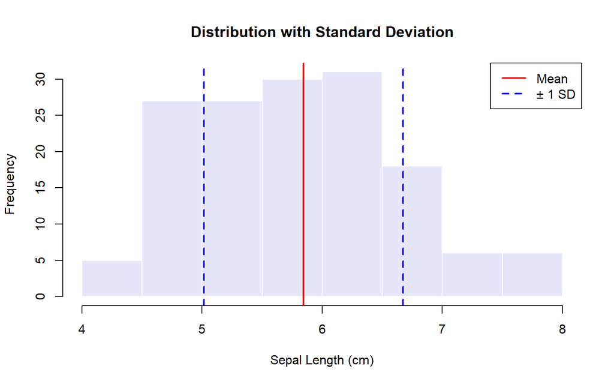

```r
# Visualize with standard deviation bands
mean_val <- mean(sepal_lengths)
hist(sepal_lengths,
     main = "Distribution with Standard Deviation",
     xlab = "Sepal Length (cm)",
     col = "lavender",
     border = "white")
abline(v = mean_val, col = "red", lwd = 2)
abline(v = mean_val - sd_value, col = "blue", lwd = 2, lty = 2)
abline(v = mean_val + sd_value, col = "blue", lwd = 2, lty = 2)
legend("topright",
       legend = c("Mean", "± 1 SD"),
       col = c("red", "blue"),
       lty = c(1, 2),
       lwd = 2)
```

**Understanding Variance and Standard Deviation:**

$$s^2 = \frac{\sum_{i=1}^{n}(x_i -
\bar{x})^2}{n-1}$$

$$s = \sqrt{s^2}$$

```r
# Manual calculation to understand the formula
deviations <- sepal_lengths - mean(sepal_lengths)
squared_deviations <- deviations^2
sum_squared_dev <- sum(squared_deviations)
manual_variance <- sum_squared_dev / (length(sepal_lengths) - 1)
manual_sd <- sqrt(manual_variance)

cat("Manual variance:", round(manual_variance, 4), "\n")
```

```
## Manual variance: 0.6857
```

```r
cat("R's var():", round(var(sepal_lengths), 4), "\n")
```

```
## R's var(): 0.6857
```

```r
cat("Manual SD:", round(manual_sd, 4), "\n")
```

```
## Manual SD: 0.8281
```

```r
cat("R's sd():", round(sd(sepal_lengths), 4), "\n")
```

```
## R's sd(): 0.8281
```

### 2.3.4 Complete Dispersion Summary

```r
# Comprehensive dispersion measures
dispersion_summary <- data.frame(
  Measure = c("Range", "IQR", "Variance", "Std Dev", "Coef of Variation"),
  Value = c(
    diff(range(sepal_lengths)),
    IQR(sepal_lengths),
    var(sepal_lengths),
    sd(sepal_lengths),
    sd(sepal_lengths) / mean(sepal_lengths) * 100
  ),
  Unit = c("cm", "cm", "cm²", "cm", "%")
)

dispersion_summary %>%
  mutate(Value = round(Value, 3)) %>%
  kable(caption = "Measures of Dispersion for Sepal Length") %>%
  kable_styling(bootstrap_options = c("striped", "hover"))
```

Measures of Dispersion for Sepal Length

| Measure | Value | Unit |
| --- | --- | --- |
| Range | 3.600 | cm |
| IQR | 1.300 | cm |
| Variance | 0.686 | cm² |
| Std Dev | 0.828 | cm |
| Coef of Variation | 14.171 | % |

## 2.4 Frequency Distributions

```r
# Create frequency table
sepal_length_cut <- cut(sepal_lengths, breaks = 8)
freq_table <- table(sepal_length_cut)

cat("Frequency Distribution:\n")
```

```
## Frequency Distribution:
```

```r
print(freq_table)
```

```
## sepal_length_cut
## (4.3,4.75] (4.75,5.2] (5.2,5.65] (5.65,6.1] (6.1,6.55]   (6.55,7]   (7,7.45]
##         11         34         20         30         25         18          6
## (7.45,7.9]
##          6
```

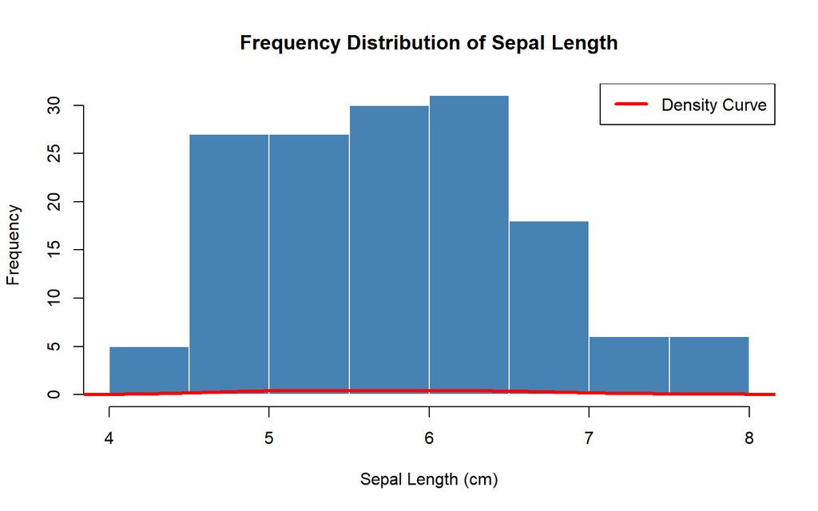

```r
# Create histogram with frequency
hist(sepal_lengths,
     main = "Frequency Distribution of Sepal Length",
     xlab = "Sepal Length (cm)",
     ylab = "Frequency",
     col = "steelblue",
     border = "white",
     breaks = 12)

# Add density curve
lines(density(sepal_lengths), col = "red", lwd = 3)
legend("topright", legend = "Density Curve", col = "red", lwd = 3)
```

### 2.4.1 Distribution Shapes

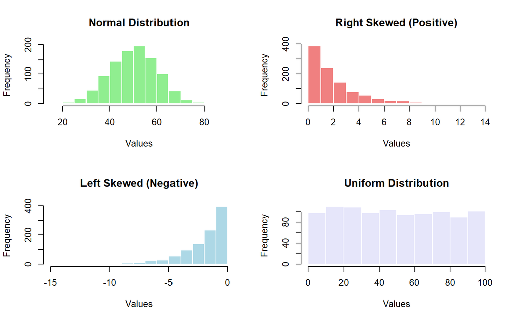

```r
# Create different distribution shapes
par(mfrow = c(2, 2))

# Normal distribution
normal_data <- rnorm(1000, mean = 50, sd = 10)
hist(normal_data, main = "Normal Distribution",
     col = "lightgreen", border = "white", xlab = "Values")

# Right-skewed (positive skew)
skewed_right <- rexp(1000, rate = 0.5)
hist(skewed_right, main = "Right Skewed (Positive)",
     col = "lightcoral", border = "white", xlab = "Values")

# Left-skewed (negative skew)
skewed_left <- -rexp(1000, rate = 0.5)
hist(skewed_left, main = "Left Skewed (Negative)",
     col = "lightblue", border = "white", xlab = "Values")

# Uniform distribution
uniform_data <- runif(1000, min = 0, max = 100)
hist(uniform_data, main = "Uniform Distribution",
     col = "lavender", border = "white", xlab = "Values")
```

```r
par(mfrow = c(1, 1))
```

### 2.4.2 Describing Distribution Shape

```r
library(moments)  # For skewness and kurtosis

# Calculate shape statistics
skewness_val <- skewness(sepal_lengths)
kurtosis_val <- kurtosis(sepal_lengths)

cat("Skewness:", round(skewness_val, 3), "\n")
```

```
## Skewness: 0.312
```

```r
cat("Interpretation:",
    ifelse(abs(skewness_val) < 0.5, "Approximately Symmetric",
           ifelse(skewness_val > 0, "Right-skewed (Positive)", "Left-skewed (Negative)")), "\n\n")
```

```
## Interpretation: Approximately Symmetric
```

```r
cat("Kurtosis:", round(kurtosis_val, 3), "\n")
```

```
## Kurtosis: 2.426
```

```r
cat("Interpretation:",
    ifelse(kurtosis_val > 3, "Leptokurtic (heavy tails)",
           ifelse(kurtosis_val < 3, "Platykurtic (light tails)", "Mesokurtic (normal)")), "\n")
```

```
## Interpretation: Platykurtic (light tails)
```

# Part 3: Exploratory Data Analysis

## 3.1 Summary Statistics

```r
# Comprehensive summary statistics
cat("=== IRIS DATASET SUMMARY ===\n\n")
```

```
## === IRIS DATASET SUMMARY ===
```

```r
summary(iris)
```

```
##   Sepal.Length    Sepal.Width     Petal.Length    Petal.Width
##  Min.   :4.300   Min.   :2.000   Min.   :1.000   Min.   :0.100
##  1st Qu.:5.100   1st Qu.:2.800   1st Qu.:1.600   1st Qu.:0.300
##  Median :5.800   Median :3.000   Median :4.350   Median :1.300
##  Mean   :5.843   Mean   :3.057   Mean   :3.758   Mean   :1.199
##  3rd Qu.:6.400   3rd Qu.:3.300   3rd Qu.:5.100   3rd Qu.:1.800
##  Max.   :7.900   Max.   :4.400   Max.   :6.900   Max.   :2.500
##        Species
##  setosa    :50
##  versicolor:50
##  virginica :50
##
##
##
```

```r
# More detailed summary by species
iris_detailed <- iris %>%
  group_by(Species) %>%
  summarise(
    N = n(),
    Mean_Sepal_Length = mean(Sepal.Length),
    SD_Sepal_Length = sd(Sepal.Length),
    Mean_Sepal_Width = mean(Sepal.Width),
    SD_Sepal_Width = sd(Sepal.Width),
    Mean_Petal_Length = mean(Petal.Length),
    SD_Petal_Length = sd(Petal.Length)
  ) %>%
  mutate(across(where(is.numeric), ~round(., 2)))

iris_detailed %>%
  kable(caption = "Detailed Summary by Species") %>%
  kable_styling(bootstrap_options = c("striped", "hover")) %>%
  scroll_box(width = "100%")
```

Detailed Summary by Species

| Species | N | Mean_Sepal_Length | SD_Sepal_Length | Mean_Sepal_Width | SD_Sepal_Width | Mean_Petal_Length | SD_Petal_Length |
| --- | --- | --- | --- | --- | --- | --- | --- |
| setosa | 50 | 5.01 | 0.35 | 3.43 | 0.38 | 1.46 | 0.17 |
| versicolor | 50 | 5.94 | 0.52 | 2.77 | 0.31 | 4.26 | 0.47 |
| virginica | 50 | 6.59 | 0.64 | 2.97 | 0.32 | 5.55 | 0.55 |

## 3.2 Data Visualization

### 3.2.1 Univariate Analysis

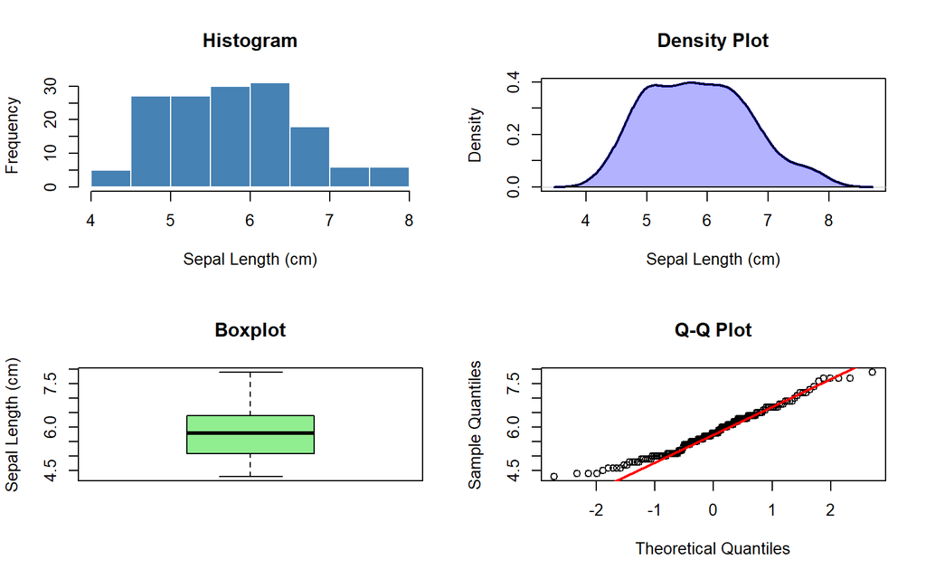

```r
# Multiple ways to visualize single variable
par(mfrow = c(2, 2))

# Histogram
hist(iris$Sepal.Length,
     main = "Histogram",
     xlab = "Sepal Length (cm)",
     col = "steelblue",
     border = "white")

# Density plot
plot(density(iris$Sepal.Length),
     main = "Density Plot",
     xlab = "Sepal Length (cm)",
     lwd = 2,
     col = "darkblue")
polygon(density(iris$Sepal.Length), col = rgb(0, 0, 1, 0.3))

# Boxplot
boxplot(iris$Sepal.Length,
        main = "Boxplot",
        ylab = "Sepal Length (cm)",
        col = "lightgreen")

# Q-Q plot (check normality)
qqnorm(iris$Sepal.Length, main = "Q-Q Plot")
qqline(iris$Sepal.Length, col = "red", lwd = 2)
```

```r
par(mfrow = c(1, 1))
```

### 3.2.2 Bivariate Analysis

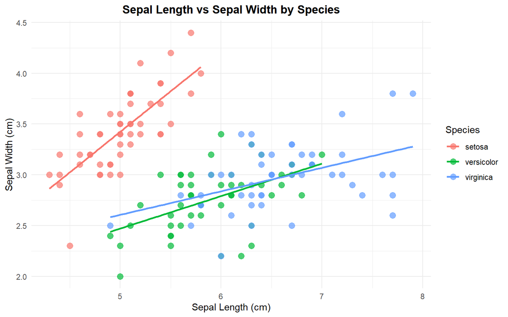

```r
# Relationship between two variables
ggplot(iris, aes(x = Sepal.Length, y = Sepal.Width, color = Species)) +
  geom_point(size = 3, alpha = 0.7) +
  geom_smooth(method = "lm", se = FALSE) +
  labs(
    title = "Sepal Length vs Sepal Width by Species",
    x = "Sepal Length (cm)",
    y = "Sepal Width (cm)"
  ) +
  theme_minimal() +
  theme(plot.title = element_text(hjust = 0.5, face = "bold"))
```

### 3.2.3 Multivariate Analysis

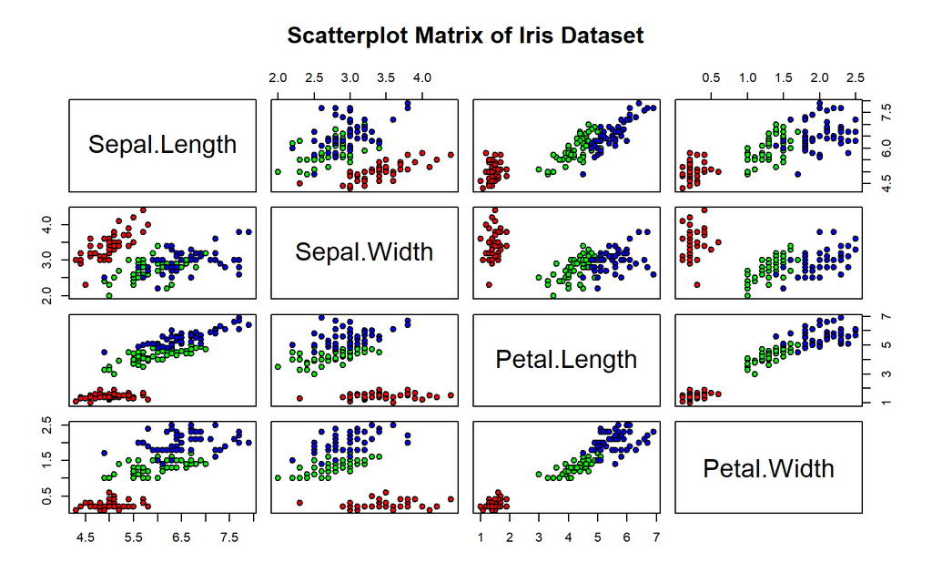

```r
# Pairs plot for multiple variables
pairs(iris[, 1:4],
      main = "Scatterplot Matrix of Iris Dataset",
      pch = 21,
      bg = c("red", "green", "blue")[unclass(iris$Species)])
```

### 3.2.4 Advanced ggplot2 Visualizations

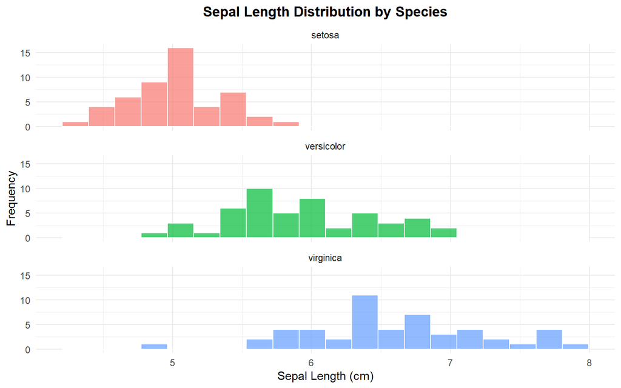

```r
# Faceted visualization
ggplot(iris, aes(x = Sepal.Length, fill = Species)) +
  geom_histogram(bins = 20, alpha = 0.7, color = "white") +
  facet_wrap(~Species, ncol = 1) +
  labs(
    title = "Sepal Length Distribution by Species",
    x = "Sepal Length (cm)",
    y = "Frequency"
  ) +
  theme_minimal() +
  theme(
    plot.title = element_text(hjust = 0.5, face = "bold"),
    legend.position = "none"
  )
```

## 3.3 Data Quality Checks

```r
# Check for missing values
cat("=== MISSING VALUES CHECK ===\n")
```

```
## === MISSING VALUES CHECK ===
```

```r
missing_summary <- data.frame(
  Variable = names(iris),
  Missing_Count = colSums(is.na(iris)),
  Missing_Percent = round(colSums(is.na(iris)) / nrow(iris) * 100, 2)
)

missing_summary %>%
  kable(caption = "Missing Values Summary") %>%
  kable_styling(bootstrap_options = c("striped", "hover"))
```

Missing Values Summary

|  | Variable | Missing_Count | Missing_Percent |
| --- | --- | --- | --- |
| Sepal.Length | Sepal.Length | 0 | 0 |
| Sepal.Width | Sepal.Width | 0 | 0 |
| Petal.Length | Petal.Length | 0 | 0 |
| Petal.Width | Petal.Width | 0 | 0 |
| Species | Species | 0 | 0 |

```r
# Check for outliers using IQR method
detect_outliers <- function(x) {
  q1 <- quantile(x, 0.25)
  q3 <- quantile(x, 0.75)
  iqr <- q3 - q1
  lower_bound <- q1 - 1.5 * iqr
  upper_bound <- q3 + 1.5 * iqr
  sum(x < lower_bound | x > upper_bound)
}

cat("\n=== OUTLIER DETECTION ===\n")
```

```
##
## === OUTLIER DETECTION ===
```

```r
outlier_summary <- iris %>%
  select(where(is.numeric)) %>%
  summarise(across(everything(), detect_outliers)) %>%
  pivot_longer(everything(), names_to = "Variable", values_to = "Outlier_Count")

outlier_summary %>%
  kable(caption = "Outlier Count by Variable (IQR Method)") %>%
  kable_styling(bootstrap_options = c("striped", "hover"))
```

Outlier Count by Variable (IQR Method)

| Variable | Outlier_Count |
| --- | --- |
| Sepal.Length | 0 |
| Sepal.Width | 4 |
| Petal.Length | 0 |
| Petal.Width | 0 |